# Scraping Weather Data for Bordeaux and Antibes

Antoine.P _ August 2017

We are going to use the package ‘weatherData’ in R to scrap one of Data souces we need to keep building the Context Aware Reccomendation System for restaurant sector.

Firstly, we try to do some weather data analysis with using this package which can be founded at: “https://ram-n.github.io/weatherData/example_weatherYear.html”

( 2nd solution with PYTHON : Wunderground Data with Python Pandas & Seaborn Tutorial /Shane Lynn)

```r
library(weatherData)
city1 <- "BOD"
df1 <- getWeatherForYear(city1,2016)
```

```
URL to Try:
 https://www.wunderground.com/history/airport/BOD/2016/1/1/CustomHistory.html?dayend=31&monthend=12&yearend=2016&req_city=NA&req_state=NA&req_statename=NA&format=1

Retrieving from: https://www.wunderground.com/history/airport/BOD/2016/1/1/CustomHistory.html?dayend=31&monthend=12&yearend=2016&req_city=NA&req_state=NA&req_statename=NA&format=1
```

```
[1] 360
```

```
The following columns are available:
```

```
 [1] "X_0545"                     "Max_TemperatureC"           "Mean_TemperatureC"          "Min_TemperatureC"           "Dew_PointC"                 "MeanDew_PointC"
 [7] "Min_DewpointC"              "Max_Humidity"               "Mean_Humidity"              "Min_Humidity"               "Max_Sea_Level_PressurehPa"  "Mean_Sea_Level_PressurehPa"
[13] "Min_Sea_Level_PressurehPa"  "Max_VisibilityKm"           "Mean_VisibilityKm"          "Min_VisibilitykM"           "Max_Wind_SpeedKm_h"         "Mean_Wind_SpeedKm_h"
[19] "Max_Gust_SpeedKm_h"         "Precipitationmm"            "CloudCover"                 "Events"                     "WindDirDegrees"
```

```
Preview of the data available...
```

```
[1] 359  23
    X_0545 Max_TemperatureC Mean_TemperatureC Min_TemperatureC Dew_PointC MeanDew_PointC Min_DewpointC Max_Humidity Mean_Humidity Min_Humidity Max_Sea_Level_PressurehPa
1 2016-1-1               22                13                4         11              8             6           94            64           37                      1022
2 2016-1-2               22                13                4         11              8             5           95            63           33                      1022
3 2016-1-3               22                13                5         11              8             6           99            65           30                      1019
4 2016-1-4               22                12                5         11              8             6           94            72           48                      1021
5 2016-1-5               23                15                7         11              9             7           91            67           33                      1018
6 2016-1-6               24                14                5         12              9             6           94            61           30                      1019
  Mean_Sea_Level_PressurehPa Min_Sea_Level_PressurehPa Max_VisibilityKm Mean_VisibilityKm Min_VisibilitykM Max_Wind_SpeedKm_h Mean_Wind_SpeedKm_h Max_Gust_SpeedKm_h Precipitationmm
1                       1020                      1019                8                 6                3                 11                   2                 NA               0
2                       1020                      1017                8                 7                2                 10                   2                 NA               0
3                       1017                      1015               10                 7                6                 13                   6                 NA               0
4                       1015                      1002                8                 6                2                  8                   2                 NA               0
5                       1016                      1014               10                 7                6                 13                   3                 NA               0
6                       1017                      1016                8                 6                2                 21                   6                 NA               0
  CloudCover Events WindDirDegrees
1         NA                    -1
2         NA    Fog             -1
3         NA                    -1
4         NA    Fog             -1
5         NA                    -1
6         NA                    -1
```

```
Desired Columns Requested:
```

```
[1] 24  2  3  4
```

```
Checking Summarized Data Availability For BOD
Found 359 records for 2016-01-01 to 2016-12-31
Data is Available for the interval.
Will be fetching these Columns:
```

```
[1] "Date"              "Max_TemperatureC"  "Mean_TemperatureC" "Min_TemperatureC"
```

```r
head(df1,3)
```

|  | Date | Max_TemperatureC | Mean_TemperatureC | Min_TemperatureC |
| --- | --- | --- | --- | --- |
| 1 |  | 22 | 13 | 4 |
| 2 |  | 22 | 13 | 4 |
| 3 |  | 22 | 13 | 5 |

```r
city2 <- "NCE"
df2 <- getWeatherForYear(city2, 2016)
```

```
URL to Try:
 https://www.wunderground.com/history/airport/NCE/2016/1/1/CustomHistory.html?dayend=31&monthend=12&yearend=2016&req_city=NA&req_state=NA&req_statename=NA&format=1

Retrieving from: https://www.wunderground.com/history/airport/NCE/2016/1/1/CustomHistory.html?dayend=31&monthend=12&yearend=2016&req_city=NA&req_state=NA&req_statename=NA&format=1
```

```
[1] 367
```

```
The following columns are available:
```

```
 [1] "CET"                        "Max_TemperatureC"           "Mean_TemperatureC"          "Min_TemperatureC"           "Dew_PointC"                 "MeanDew_PointC"
 [7] "Min_DewpointC"              "Max_Humidity"               "Mean_Humidity"              "Min_Humidity"               "Max_Sea_Level_PressurehPa"  "Mean_Sea_Level_PressurehPa"
[13] "Min_Sea_Level_PressurehPa"  "Max_VisibilityKm"           "Mean_VisibilityKm"          "Min_VisibilitykM"           "Max_Wind_SpeedKm_h"         "Mean_Wind_SpeedKm_h"
[19] "Max_Gust_SpeedKm_h"         "Precipitationmm"            "CloudCover"                 "Events"                     "WindDirDegrees"
```

```
Preview of the data available...
```

```
[1] 366  23
       CET Max_TemperatureC Mean_TemperatureC Min_TemperatureC Dew_PointC MeanDew_PointC Min_DewpointC Max_Humidity Mean_Humidity Min_Humidity Max_Sea_Level_PressurehPa
1 2016-1-1               12                10                9          7              5             4           87            66           49                      1026
2 2016-1-2               13                11                8         10              8             7           93            85           77                      1022
3 2016-1-3               13                 9                6          7              4             2           87            68           38                      1010
4 2016-1-4               15                11                8          6              4             2           76            59           36                      1005
5 2016-1-5               14                11                8          9              5             2           82            66           38                      1000
6 2016-1-6               13                 9                6          5              2            -1           81            61           37                      1002
  Mean_Sea_Level_PressurehPa Min_Sea_Level_PressurehPa Max_VisibilityKm Mean_VisibilityKm Min_VisibilitykM Max_Wind_SpeedKm_h Mean_Wind_SpeedKm_h Max_Gust_SpeedKm_h Precipitationmm
1                       1025                      1022               26                11                2                 13                  10                 NA            2.03
2                       1014                      1010               19                 9                3                 14                  10                 NA            7.11
3                       1008                      1004               31                14               10                 24                  11                 NA            0.00
4                        998                       995               27                11               10                 45                  19                 NA            0.00
5                        998                       996               19                11               10                 24                  13                 NA            0.00
6                       1000                       999               27                12               10                 23                  14                 NA            0.00
  CloudCover Events WindDirDegrees
1          7   Rain            348
2          7   Rain            343
3          4                   318
4          6                   293
5          6   Rain              2
6          4                   335
```

```
Desired Columns Requested:
```

```
[1] 24  2  3  4
```

```
Checking Summarized Data Availability For NCE
Found 366 records for 2016-01-01 to 2016-12-31
Data is Available for the interval.
Will be fetching these Columns:
```

```
[1] "Date"              "Max_TemperatureC"  "Mean_TemperatureC" "Min_TemperatureC"
```

```r
head(df2,3)
```

|  | Date | Max_TemperatureC | Mean_TemperatureC | Min_TemperatureC |
| --- | --- | --- | --- | --- |
| 1 |  | 12 | 10 | 9 |
| 2 |  | 13 | 11 | 8 |
| 3 |  | 13 | 9 | 6 |

```r
a<-df1$Date
b<-df2$Date
manque_data<-b[!(b %in% a)]# to find out records in b but not in a
df22<-subset(df2,!(Date %in% c('2016-04-03','2016-04-04', '2016-05-12', '2016-10-29' ,'2016-11-19', '2016-11-20',  '2016-11-21')))
```

```r
getDailyDifferences <- function(df1, df22){
  Delta_Means <- df1$Mean_TemperatureC - df22$Mean_TemperatureC
  Delta_Max <- df1$Max_TemperatureC - df22$Max_TemperatureC
  Delta_Min <- df1$Min_TemperatureC - df22$Min_TemperatureC

  diff_df <- data.frame(Date=df1$Date, Delta_Means, Delta_Max, Delta_Min)
  return(diff_df)
}
```

```r
plotDifferences <- function (differences, city1, city2) {
library(reshape2)
  m.diff <- melt(differences, id.vars=c("Date"))
  p <- ggplot(m.diff, aes(x=Date, y=value)) + geom_point(aes(color=variable)) +
    facet_grid(variable ~ .) +geom_hline(yintercept=0)
  p <- p + labs(title=paste0("Daily Temperature Differences: ", "Bordeaux", " minus ","Nice"))
  print(p)
}
```

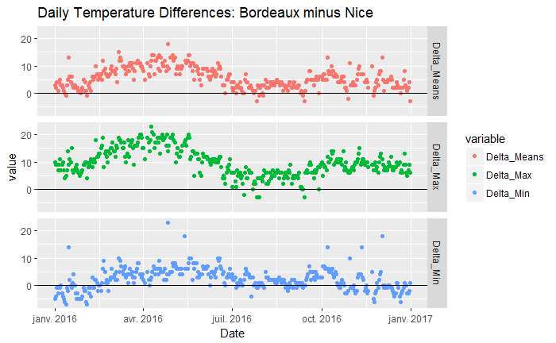

```r
library(ggplot2)
differences<- getDailyDifferences(df1, df22)
plotDifferences(differences, city1, city2)
```

SCRAPING DATA FOR OUR PROJECT

First, get the station code of Bordeaux

```r
getStationCode("Bordeaux")
```

|  | Station | State | airportCode |
| --- | --- | --- | --- |
| 1547 | Bordeaux | WY | KBRX |

```
[[2]]
[1] "USA WY BORDEAUX         KBRX  BRX          41 57N  104 57W 1524   X           M    9 US"     " FRANCE    BORDEAUX/MERIGNA LFBD        07510  44 49N  000 42W   61   X     T  X       6 FR"
```

The code of Bordeaux is ‘LFBD’.

Now, which columns relate to our project?

```r
bor_rawdat<-getWeatherForDate("LFBD",start_date = "2016-01-01",end_date = "2017-08-30",opt_detailed = TRUE)
```

```
Getting data from:
 https://www.wunderground.com/history/airport/LFBD/2016/1/1/DailyHistory.html?format=1
```

```
[1] 73
```

```
The following columns are available for:2016-01-01
```

```
 [1] "TimeCET"               "TemperatureC"          "Dew_PointC"            "Humidity"              "Sea_Level_PressurehPa" "VisibilityKm"          "Wind_Direction"
 [8] "Wind_SpeedKm_h"        "Gust_SpeedKm_h"        "Precipitationmm"       "Events"                "Conditions"            "WindDirDegrees"        "DateUTC"
[1] 36 14
        V1 V2 V3  V4   V5      V6    V7  V8 V9 V10 V11            V12 V13                 V14
1 12:00 AM  7  6  95 1026      NA South 5.6        Fog Patches of Fog 170 2015-12-31 23:00:00
2 12:30 AM  6  6 100 1025 -9999.0   ESE 5.6  - N/A               Mist 120 2015-12-31 23:30:00
3  1:00 AM  6  5  93 1025     0.6   ESE 5.6  - N/A Fog            Fog 120 2016-01-01 00:00:00
4  2:00 AM  5  4  95 1026      NA   ESE 5.6        Fog    Partial Fog 110 2016-01-01 01:00:00
5  2:30 AM  5  4  93 1025     0.4   ESE 5.6  - N/A Fog            Fog 110 2016-01-01 01:30:00
6  3:00 AM  5  4  93 1025     0.7  East 7.4  - N/A Fog            Fog 100 2016-01-01 02:00:00
```

```
Getting data from:
 https://www.wunderground.com/history/airport/LFBD/2017/8/30/DailyHistory.html?format=1
```

```
[1] 69
```

```
The following columns are available for:2017-08-30
```

```
 [1] "TimeCEST"              "TemperatureC"          "Dew_PointC"            "Humidity"              "Sea_Level_PressurehPa" "VisibilityKm"          "Wind_Direction"
 [8] "Wind_SpeedKm_h"        "Gust_SpeedKm_h"        "Precipitationmm"       "Events"                "Conditions"            "WindDirDegrees"        "DateUTC"
[1] 34 14
        V1 V2 V3 V4   V5    V6       V7   V8 V9 V10 V11           V12 V13                 V14
1 12:00 AM 21 18 79 1013    45       NW  9.3                    Clear 310 2017-08-29 22:00:00
2 12:30 AM 21 19 88 1013 -9999      WNW  7.4  - N/A             Clear 300 2017-08-29 22:30:00
3  1:00 AM 21 19 88 1013 -9999     Calm Calm  - N/A             Clear   0 2017-08-29 23:00:00
4  2:00 AM 21 19 86 1014    20      WSW  7.4                    Clear 250 2017-08-30 00:00:00
5  2:30 AM 21 19 88 1013    10 Variable  5.6  - N/A          Overcast   0 2017-08-30 00:30:00
6  3:00 AM 21 19 88 1014    10      WSW  9.3  - N/A     Mostly Cloudy 240 2017-08-30 01:00:00
```

```
Checking Data Availability For LFBD
Found 36 records for 2016-01-01
Found 34 records for 2017-08-30

Data is Available for the interval.

Will be fetching these Columns:
```

```
[1] "Time"         "TemperatureC"
```

[output not shown]

[output cut: 554 more lines]

[output not shown]

However we are also interested in columns: 2,4,7,12,14.

Please note that the column numbers are very different depending on whether or not opt_detailed is TRUE or FALSE.

When fetching the data, we have to set opt_custom_columns=TRUE and custom_columns=c(2,4,,7,12,14).

We are now ready to actually fetch the data.

```r
bor_rawdat<-getWeatherForDate("LFBD",start_date = "2016-01-01",end_date = "2017-08-30",opt_detailed = TRUE,opt_custom_columns=T, custom_columns=c(2,4,7,12,14))
```

```
Getting data from:
 https://www.wunderground.com/history/airport/LFBD/2016/1/1/DailyHistory.html?format=1
```

```
[1] 73
```

```
The following columns are available for:2016-01-01
```

```
 [1] "TimeCET"               "TemperatureC"          "Dew_PointC"            "Humidity"              "Sea_Level_PressurehPa" "VisibilityKm"          "Wind_Direction"
 [8] "Wind_SpeedKm_h"        "Gust_SpeedKm_h"        "Precipitationmm"       "Events"                "Conditions"            "WindDirDegrees"        "DateUTC"
[1] 36 14
        V1 V2 V3  V4   V5      V6    V7  V8 V9 V10 V11            V12 V13                 V14
1 12:00 AM  7  6  95 1026      NA South 5.6        Fog Patches of Fog 170 2015-12-31 23:00:00
2 12:30 AM  6  6 100 1025 -9999.0   ESE 5.6  - N/A               Mist 120 2015-12-31 23:30:00
3  1:00 AM  6  5  93 1025     0.6   ESE 5.6  - N/A Fog            Fog 120 2016-01-01 00:00:00
4  2:00 AM  5  4  95 1026      NA   ESE 5.6        Fog    Partial Fog 110 2016-01-01 01:00:00
5  2:30 AM  5  4  93 1025     0.4   ESE 5.6  - N/A Fog            Fog 110 2016-01-01 01:30:00
6  3:00 AM  5  4  93 1025     0.7  East 7.4  - N/A Fog            Fog 100 2016-01-01 02:00:00
```

```
Getting data from:
 https://www.wunderground.com/history/airport/LFBD/2017/8/30/DailyHistory.html?format=1
```

```
[1] 69
```

```
The following columns are available for:2017-08-30
```

```
 [1] "TimeCEST"              "TemperatureC"          "Dew_PointC"            "Humidity"              "Sea_Level_PressurehPa" "VisibilityKm"          "Wind_Direction"
 [8] "Wind_SpeedKm_h"        "Gust_SpeedKm_h"        "Precipitationmm"       "Events"                "Conditions"            "WindDirDegrees"        "DateUTC"
[1] 34 14
        V1 V2 V3 V4   V5    V6       V7   V8 V9 V10 V11           V12 V13                 V14
1 12:00 AM 21 18 79 1013    45       NW  9.3                    Clear 310 2017-08-29 22:00:00
2 12:30 AM 21 19 88 1013 -9999      WNW  7.4  - N/A             Clear 300 2017-08-29 22:30:00
3  1:00 AM 21 19 88 1013 -9999     Calm Calm  - N/A             Clear   0 2017-08-29 23:00:00
4  2:00 AM 21 19 86 1014    20      WSW  7.4                    Clear 250 2017-08-30 00:00:00
5  2:30 AM 21 19 88 1013    10 Variable  5.6  - N/A          Overcast   0 2017-08-30 00:30:00
6  3:00 AM 21 19 88 1014    10      WSW  9.3  - N/A     Mostly Cloudy 240 2017-08-30 01:00:00
```

```
Checking Data Availability For LFBD
Found 36 records for 2016-01-01
Found 34 records for 2017-08-30

Data is Available for the interval.

Will be fetching these Columns:
```

```
[1] "Time"           "TemperatureC"   "Humidity"       "Wind_Direction" "Conditions"     "DateUTC"
```

[output not shown]

[output cut: 554 more lines]

[output not shown]

```r
head(bor_rawdat)
```

|  | Time | TemperatureC | Humidity | Wind_Direction | Conditions | DateUTC |
| --- | --- | --- | --- | --- | --- | --- |
| 1 | 2016-01-01 00:00:00 | 7 | 95 | South | Patches of Fog | 2015-12-31 23:00:00 |
| 2 | 2016-01-01 00:00:00 | 7 | 93 | South | Unknown | 2015-12-31 23:00:00 |
| 3 | 2016-01-01 00:30:00 | 6 | 100 | ESE | Mist | 2015-12-31 23:30:00 |
| 4 | 2016-01-01 01:00:00 | 6 | 98 | ESE | Partial Fog | 2016-01-01 00:00:00 |
| 5 | 2016-01-01 01:00:00 | 6 | 93 | ESE | Fog | 2016-01-01 00:00:00 |
| 6 | 2016-01-01 01:30:00 | 5 | 100 | SE | Fog | 2016-01-01 00:30:00 |

```r
dim(bor_rawdat)
```

```
[1] 42920     6
```

DOING THE SAME ACTION FOR ANTIBES

```r
getStationCode("Antibes")
```

IBONSON2

```r
showAvailableColumns("Antibes", start_date = "2016-01-01",end_date = "2017-08-30" )
```

| columnNumber | columnName |
| --- | --- |
| 1 | CET |
| 2 | Max_TemperatureC |
| 3 | Mean_TemperatureC |
| 4 | Min_TemperatureC |
| 5 | Dew_PointC |
| 6 | MeanDew_PointC |
| 7 | Min_DewpointC |
| 8 | Max_Humidity |
| 9 | Mean_Humidity |
| 10 | Min_Humidity |

[output cut: 13 more lines]

```r
antibes_rawdat<-getWeatherForDate("Antibes",start_date = "2016-01-01", end_date = "2017-08-30",opt_detailed = TRUE,opt_custom_columns=TRUE,custom_columns = c(2,4,7,12,14))
```

```
Getting data from:
 https://www.wunderground.com/history/airport/Antibes/2016/1/1/DailyHistory.html?format=1
```

```
[1] 73
```

```
The following columns are available for:2016-01-01
```

```
 [1] "TimeCET"               "TemperatureC"          "Dew_PointC"            "Humidity"              "Sea_Level_PressurehPa" "VisibilityKm"          "Wind_Direction"
 [8] "Wind_SpeedKm_h"        "Gust_SpeedKm_h"        "Precipitationmm"       "Events"                "Conditions"            "WindDirDegrees"        "DateUTC"
[1] 36 14
        V1 V2 V3 V4   V5 V6  V7   V8 V9 V10 V11      V12 V13                 V14
1 12:00 AM 10  4 59 1026 12 NNW  7.4            Overcast 330 2015-12-31 23:00:00
2 12:30 AM 10  5 71 1026 10 NNW  9.3  - N/A     Overcast 330 2015-12-31 23:30:00
3  1:00 AM 10  5 71 1025 10 NNW 11.1  - N/A     Overcast 330 2016-01-01 00:00:00
4  2:00 AM 10  5 64 1026 15 NNW  9.3            Overcast 340 2016-01-01 01:00:00
5  2:30 AM 10  5 71 1025 10 NNW  9.3  - N/A     Overcast 330 2016-01-01 01:30:00
6  3:00 AM 10  5 71 1025 10 NNW 11.1  - N/A     Overcast 340 2016-01-01 02:00:00
```

```
Getting data from:
 https://www.wunderground.com/history/airport/Antibes/2017/8/30/DailyHistory.html?format=1
```

```
[1] 71
```

```
The following columns are available for:2017-08-30
```

```
 [1] "TimeCEST"              "TemperatureC"          "Dew_PointC"            "Humidity"              "Sea_Level_PressurehPa" "VisibilityKm"          "Wind_Direction"
 [8] "Wind_SpeedKm_h"        "Gust_SpeedKm_h"        "Precipitationmm"       "Events"                "Conditions"            "WindDirDegrees"        "DateUTC"
[1] 35 14
        V1 V2 V3 V4   V5    V6  V7   V8 V9 V10 V11   V12 V13                 V14
1 12:00 AM 25 19 64 1014    20 WNW  7.4            Clear 290 2017-08-29 22:00:00
2 12:30 AM 25 18 65 1014 -9999 WNW  7.4  - N/A     Clear 300 2017-08-29 22:30:00
3  1:00 AM 25 18 65 1014 -9999  NW  7.4  - N/A     Clear 320 2017-08-29 23:00:00
4  2:00 AM 26 17 48 1014    20 NNW 11.1            Clear 340 2017-08-30 00:00:00
5  2:34 AM 26 17 57 1014 -9999 NNW  7.4  - N/A     Clear 340 2017-08-30 00:34:00
6  3:00 AM 26 17 57 1014 -9999 NNW  7.4  - N/A     Clear 340 2017-08-30 01:00:00
```

```
Checking Data Availability For Antibes
Found 36 records for 2016-01-01
Found 35 records for 2017-08-30

Data is Available for the interval.

Will be fetching these Columns:
```

```
[1] "Time"           "TemperatureC"   "Humidity"       "Wind_Direction" "Conditions"     "DateUTC"
```

[output not shown]

[output cut: 554 more lines]

[output not shown]

```r
dim(antibes_rawdat)
```

```
[1] 42463     6
```

```r
head(antibes_rawdat,3)
```

|  | Time | TemperatureC | Humidity | Wind_Direction | Conditions | DateUTC |
| --- | --- | --- | --- | --- | --- | --- |
| 1 | 2016-01-01 00:00:00 | 10 | 59 | NNW | Overcast | 2015-12-31 23:00:00 |
| 2 | 2016-01-01 00:00:00 | 10 | 71 | NNW | Overcast | 2015-12-31 23:00:00 |
| 3 | 2016-01-01 00:30:00 | 10 | 71 | NNW | Overcast | 2015-12-31 23:30:00 |

```r
tail(antibes_rawdat,3)
```

|  | Time | TemperatureC | Humidity | Wind_Direction | Conditions | DateUTC |
| --- | --- | --- | --- | --- | --- | --- |
| 42461 | 2017-08-30 23:00:00 | 26 | 78 | WSW | Clear | 2017-08-30 21:00:00 |
| 42462 | 2017-08-30 23:30:00 | 26 | 78 | SW | Light Rain Showers | 2017-08-30 21:30:00 |
| 42463 | 2017-08-30 23:41:00 | 25 | 74 | West | Clear | 2017-08-30 21:41:00 |

```r
getwd()
```

```
[1] "C:/Users/Pham Antoine"
```

EXPORTING THESE 2 DATA SETS TO CSV FILES

```r
write.csv(bor_rawdat,"Bordeaux_weather_data.csv",row.names = FALSE)
```

```r
write.csv(antibes_rawdat,"Antibes_weather_data.csv", row.names = FALSE)
```

DATA VISUALIZATION AND EXPLORATION

```r
BORdf<-read.csv("C:/Users/Pham Antoine/Bordeaux_weather_data.csv", sep = ',' )
head(BORdf,3)
```

|  | Time | TemperatureC | Humidity | Wind_Direction | Conditions | DateUTC |
| --- | --- | --- | --- | --- | --- | --- |
| 1 | 2016-01-01 00:00:00 | 7 | 95 | South | Patches of Fog | 2015-12-31 23:00:00 |
| 2 | 2016-01-01 00:00:00 | 7 | 93 | South | Unknown | 2015-12-31 23:00:00 |
| 3 | 2016-01-01 00:30:00 | 6 | 100 | ESE | Mist | 2015-12-31 23:30:00 |

```r
ANTdf<-read.csv("C:/Users/Pham Antoine/Antibes_weather_data.csv", sep = ',')
head(ANTdf,3)
```

|  | Time | TemperatureC | Humidity | Wind_Direction | Conditions | DateUTC |
| --- | --- | --- | --- | --- | --- | --- |
| 1 | 2016-01-01 00:00:00 | 10 | 59 | NNW | Overcast | 2015-12-31 23:00:00 |
| 2 | 2016-01-01 00:00:00 | 10 | 71 | NNW | Overcast | 2015-12-31 23:00:00 |
| 3 | 2016-01-01 00:30:00 | 10 | 71 | NNW | Overcast | 2015-12-31 23:30:00 |

```r
library(funModeling)
df_status(BORdf)
```

```
        variable q_zeros p_zeros q_na p_na q_inf p_inf    type unique
1           Time       0    0.00    0    0     0     0  factor  29138
2   TemperatureC     241    0.56    0    0     0     0 integer     47
3       Humidity       0    0.00    0    0     0     0 integer     95
4 Wind_Direction       0    0.00    0    0     0     0  factor     18
5     Conditions       0    0.00    0    0     0     0  factor     28
6        DateUTC       0    0.00    0    0     0     0  factor  29140
```

```r
str(BORdf)
```

```
'data.frame':   42920 obs. of  6 variables:
 $ Time          : Factor w/ 29138 levels "2016-01-01 00:00:00",..: 1 1 2 3 3 4 5 5 6 7 ...
 $ TemperatureC  : int  7 7 6 6 6 5 5 5 5 5 ...
 $ Humidity      : int  95 93 100 98 93 100 95 100 93 99 ...
 $ Wind_Direction: Factor w/ 18 levels "Calm","East",..: 11 11 4 4 4 10 4 4 4 2 ...
 $ Conditions    : Factor w/ 28 levels "","Clear","Drizzle",..: 23 28 18 21 4 4 21 4 4 7 ...
 $ DateUTC       : Factor w/ 29140 levels "2015-12-31 23:00:00",..: 1 1 2 3 3 4 5 5 6 7 ...
```

```r
summary(BORdf)
```

```
                  Time        TemperatureC      Humidity       Wind_Direction          Conditions                   DateUTC
 2016-03-27 00:00:00:    4   Min.   :-8.00   Min.   :  5.00   West    : 5013   Clear        :22444   2016-03-27 22:00:00:    4
 2016-10-30 02:00:00:    4   1st Qu.: 9.00   1st Qu.: 57.00   WSW     : 3310   Overcast     : 4954   2017-03-26 22:00:00:    4
 2017-03-26 00:00:00:    4   Median :14.00   Median : 76.00   North   : 3078   Mostly Cloudy: 4799   2015-12-31 23:00:00:    2
 2016-01-01 00:00:00:    2   Mean   :14.37   Mean   : 71.57   WNW     : 2932   Light Rain   : 2345   2016-01-01 00:00:00:    2
 2016-01-01 01:00:00:    2   3rd Qu.:19.00   3rd Qu.: 88.00   ESE     : 2730   Unknown      : 1597   2016-01-01 01:00:00:    2
 2016-01-01 02:00:00:    2   Max.   :38.00   Max.   :100.00   Variable: 2596   Partly Cloudy: 1576   2016-01-01 02:00:00:    2
 (Other)            :42902                                    (Other) :23261   (Other)      : 5205   (Other)            :42904
```

```r
df_status(ANTdf)
```

```
        variable q_zeros p_zeros q_na p_na q_inf p_inf    type unique
1           Time       0    0.00    0 0.00     0     0  factor  29186
2   TemperatureC      10    0.02   13 0.03     0     0 integer     39
3       Humidity       0    0.00    0 0.00     0     0  factor     98
4 Wind_Direction       0    0.00    0 0.00     0     0  factor     18
5     Conditions       0    0.00    0 0.00     0     0  factor     27
6        DateUTC       0    0.00    0 0.00     0     0  factor  29188
```

```r
ANTdf$Humidity<-as.integer(ANTdf$Humidity)
```

```r
str(ANTdf)
```

```
'data.frame':   42463 obs. of  6 variables:
 $ Time          : Factor w/ 29186 levels "2016-01-01 00:00:00",..: 1 1 2 3 3 4 5 5 6 7 ...
 $ TemperatureC  : int  10 10 10 10 10 9 10 10 10 10 ...
 $ Humidity      : int  53 67 67 58 67 72 59 67 67 58 ...
 $ Wind_Direction: Factor w/ 18 levels "Calm","East",..: 7 7 7 7 7 7 7 7 7 7 ...
 $ Conditions    : Factor w/ 27 levels "","Clear","Fog",..: 17 17 17 17 17 17 17 17 17 17 ...
 $ DateUTC       : Factor w/ 29188 levels "2015-12-31 23:00:00",..: 1 1 2 3 3 4 5 5 6 7 ...
```

```r
summary(ANTdf)
```

```
                  Time        TemperatureC         Humidity    Wind_Direction             Conditions                   DateUTC
 2016-03-27 00:00:00:    4   Min.   :-9999.00   Min.   : 1.0   NNW    :11681   Clear           :10974   2016-03-27 22:00:00:    4
 2016-10-30 02:00:00:    4   1st Qu.:   12.00   1st Qu.:47.0   East   : 4861   Scattered Clouds: 9941   2017-03-26 22:00:00:    4
 2017-03-26 00:00:00:    4   Median :   16.00   Median :60.0   NW     : 4275   Mostly Cloudy   : 8833   2015-12-31 23:00:00:    2
 2016-01-01 00:00:00:    2   Mean   :   10.38   Mean   :57.7   South  : 2944   Partly Cloudy   : 7910   2016-01-01 00:00:00:    2
 2016-01-01 01:00:00:    2   3rd Qu.:   23.00   3rd Qu.:70.0   ESE    : 2208                   : 2104   2016-01-01 01:00:00:    2
 2016-01-01 02:00:00:    2   Max.   :   35.00   Max.   :98.0   North  : 2132   Light Rain      : 1426   2016-01-01 02:00:00:    2
 (Other)            :42445   NA's   :13                        (Other):14362   (Other)         : 1275   (Other)            :42447
```

Checking missing values & outliers

```r
subset(ANTdf,TemperatureC< -10)
```

|  | Time | TemperatureC | Humidity | Wind_Direction | Conditions | DateUTC |
| --- | --- | --- | --- | --- | --- | --- |
| 3474 | 2016-02-19 01:00:00 | -9999 | 98 | NW | Clear | 2016-02-19 00:00:00 |
| 3475 | 2016-02-19 01:30:00 | -9999 | 98 | NNW | Clear | 2016-02-19 00:30:00 |
| 3477 | 2016-02-19 02:00:00 | -9999 | 98 | NNW | Clear | 2016-02-19 01:00:00 |
| 3478 | 2016-02-19 02:30:00 | -9999 | 98 | NW | Clear | 2016-02-19 01:30:00 |
| 3930 | 2016-02-25 11:00:00 | -9999 | 98 | ENE | Mostly Cloudy | 2016-02-25 10:00:00 |
| 3931 | 2016-02-25 11:30:00 | -9999 | 98 | East | Mostly Cloudy | 2016-02-25 10:30:00 |
| 3933 | 2016-02-25 12:00:00 | -9999 | 98 | East | Scattered Clouds | 2016-02-25 11:00:00 |
| 3935 | 2016-02-25 13:00:00 | -9999 | 98 | ESE | Scattered Clouds | 2016-02-25 12:00:00 |
| 3936 | 2016-02-25 13:30:00 | -9999 | 98 | ESE | Scattered Clouds | 2016-02-25 12:30:00 |
| 3938 | 2016-02-25 14:00:00 | -9999 | 98 | ESE | Scattered Clouds | 2016-02-25 13:00:00 |

[output cut: 18 more lines]

```r
unique(BORdf$Conditions)
```

```
 [1] Patches of Fog               Unknown                      Mist                         Partial Fog                  Fog                          Heavy Fog
 [7] Mostly Cloudy                Clear                        Overcast                     Scattered Clouds             Light Rain                   Partly Cloudy
[13] Light Rain Showers           Heavy Rain                   Rain                         Light Drizzle                Heavy Rain Showers           Light Thunderstorms and Rain
[19] Thunderstorms and Rain       Thunderstorm                                              Light Fog                    Drizzle                      Heavy Drizzle
[25] Heavy Thunderstorms and Rain Light Thunderstorm           Light Freezing Fog           Haze
28 Levels:  Clear Drizzle Fog Haze Heavy Drizzle Heavy Fog Heavy Rain Heavy Rain Showers Heavy Thunderstorms and Rain Light Drizzle Light Fog Light Freezing Fog ... Unknown
```

VISUALIZATION OF TEMPERATURE & HUMIDITY DISTRIBUTION IN BORDEAUX

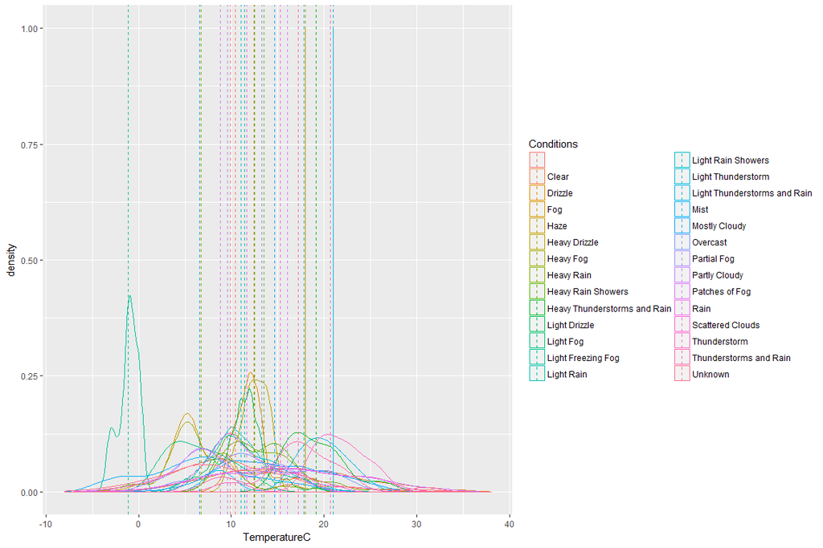

```r
library(plyr)
tm <- ddply(BORdf, "Conditions", summarise, grp.mean=mean(TemperatureC))
ggplot(BORdf,aes(x=TemperatureC))+
  geom_density(aes(group=Conditions, colour=Conditions, fill=NULL), alpha=0.8)+
  geom_vline(data=tm, aes(xintercept=grp.mean, color=Conditions),linetype="dashed")
```

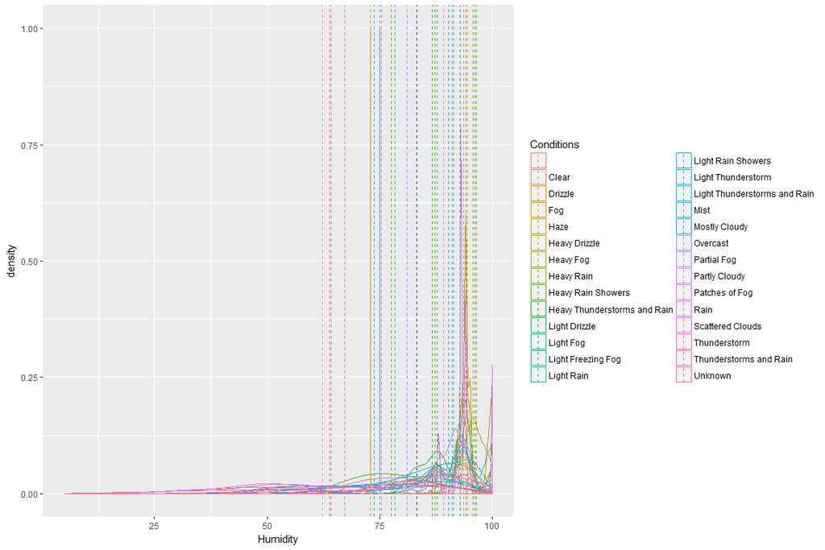

```r
tm1 <- ddply(BORdf, "Conditions", summarise, grp.mean=mean(Humidity))
ggplot(BORdf,aes(x=Humidity))+
  geom_density(aes(group=Conditions, colour=Conditions, fill=NULL), alpha=0.8)+
  geom_vline(data=tm1, aes(xintercept=grp.mean, color=Conditions),linetype="dashed")
```

VISUALIZATION OF TEMPERATURE & HUMIDITY DISTRIBUTION IN ANTIBES

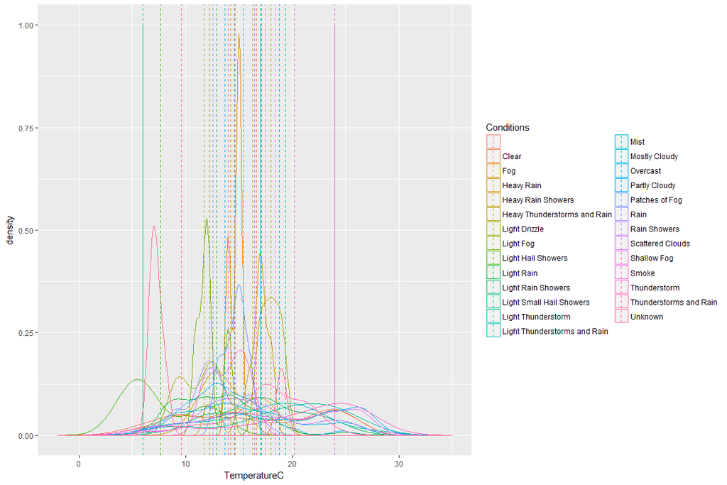

```r
t=subset(ANTdf,TemperatureC> -10)# for ignoring records having outliers=-9999 as temperature
tn<- ddply(t, "Conditions", summarise, grp.mean=mean(TemperatureC))
ggplot(t,aes(x=TemperatureC))+
  geom_density(aes(group=Conditions, colour=Conditions, fill=NULL), alpha=0.8)+
  geom_vline(data=tn, aes(xintercept=grp.mean, color=Conditions),linetype="dashed")
```

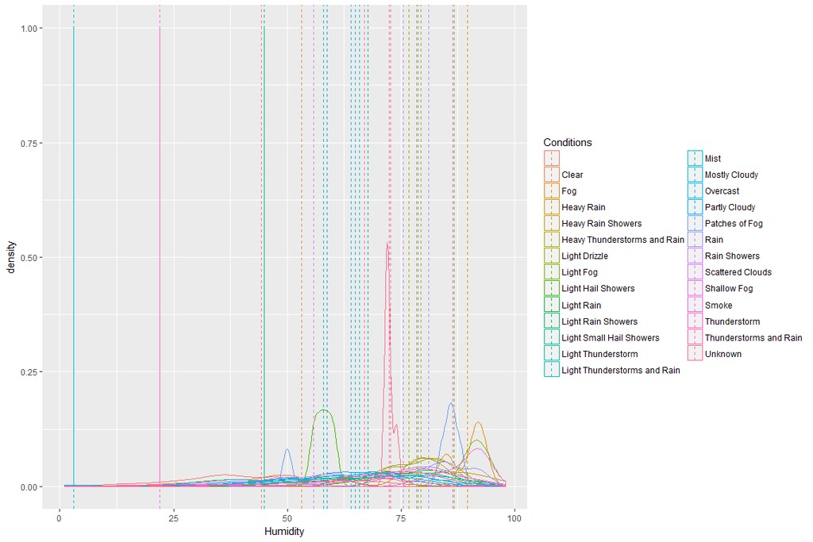

```r
tn1<- ddply(ANTdf, "Conditions", summarise, grp.mean=mean(Humidity))
ggplot(ANTdf,aes(x=Humidity))+
  geom_density(aes(group=Conditions, colour=Conditions, fill=NULL), alpha=0.8)+
  geom_vline(data=tn1, aes(xintercept=grp.mean, color=Conditions),linetype="dashed")
```

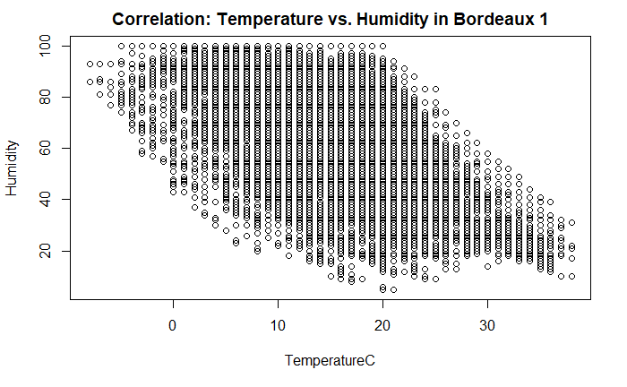

```r
library(UsingR)
attach(BORdf)
plot(TemperatureC,Humidity,main=paste("Correlation: Temperature vs. Humidity in Bordeaux",signif(cor(TemperatureC,TemperatureC),2)))
```

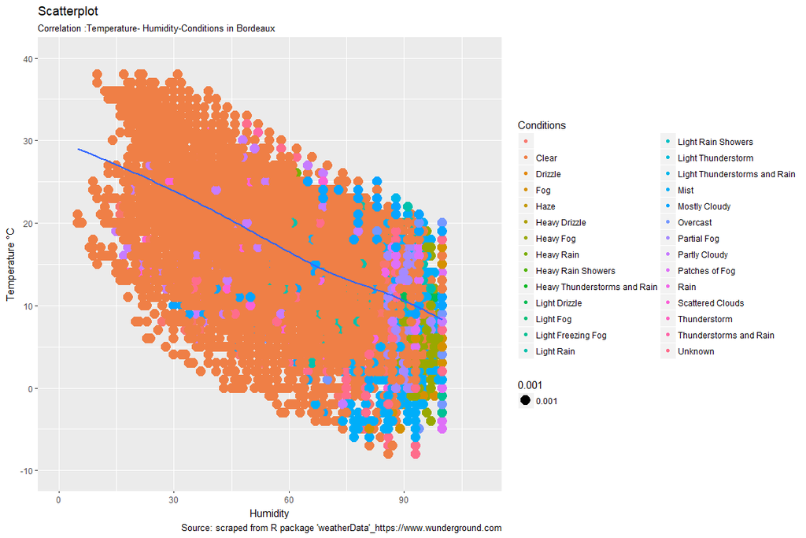

```r
gg <- ggplot(BORdf, aes(x=Humidity, y=TemperatureC)) +
geom_point(aes(col=Conditions,size=0.001)) +
geom_smooth(method="loess", se=F) +
xlim(c(0, 110)) +
ylim(c(-10, 40)) +
labs(subtitle="Correlation :Temperature- Humidity-Conditions in Bordeaux",
y="Temperature °C",
x="Humidity",
title="Scatterplot",
caption = "Source: scraped from R package 'weatherData'_https://www.wunderground.com")
plot(gg)
```

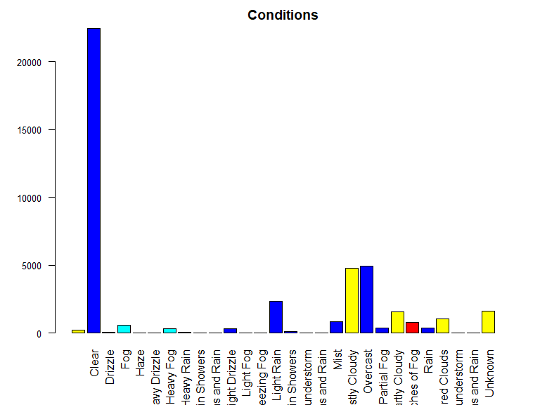

```r
barplot(table(BORdf$Conditions),
        main= 'Conditions',las=2,col = BORdf$Conditions,cex.axis=0.8,cex.names=1)#las=2 for ajusting the angle of texts:https://stackoverflow.com/questions/10286473/rotating-x-axis-labels-in-r-for-barplot
```

```r
#,
 #       col= c(len(BORdf$Conditions)))
#, legend.text =c("0 = Non","1 = Partielle","2 = Totale"),xlab="Type de resiliation", ylab="Nombre de contrats",ylim=c(0,150000), beside=TRUE,args.legend = list(x="topright",title= "Type", cex=0.6))
```

```r
table(BORdf$Conditions)
```

```
                                                    Clear                      Drizzle                          Fog                         Haze                Heavy Drizzle
                         199                        22444                           89                          562                            1                           10
                   Heavy Fog                   Heavy Rain           Heavy Rain Showers Heavy Thunderstorms and Rain                Light Drizzle                    Light Fog
                         306                           44                           12                           11                          301                            9
          Light Freezing Fog                   Light Rain           Light Rain Showers           Light Thunderstorm Light Thunderstorms and Rain                         Mist
                          20                         2345                          114                            1                           16                          846
               Mostly Cloudy                     Overcast                  Partial Fog                Partly Cloudy               Patches of Fog                         Rain
                        4799                         4954                          380                         1576                          786                          401
            Scattered Clouds                 Thunderstorm       Thunderstorms and Rain                      Unknown
                        1049                           22                           26                         1597
```

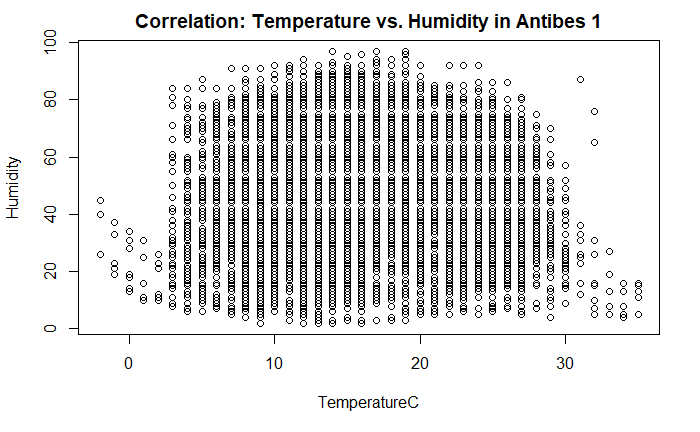

```r
library(UsingR)
attach(t)
plot(TemperatureC,Humidity,main=paste("Correlation: Temperature vs. Humidity in Antibes",signif(cor(TemperatureC,TemperatureC),2)))
```

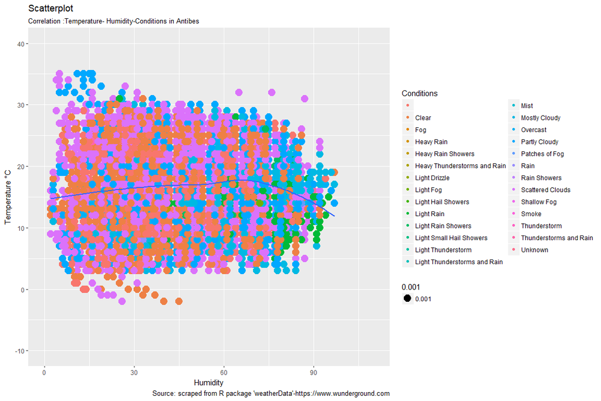

```r
gq <- ggplot(t, aes(x=Humidity, y=TemperatureC)) +
geom_point(aes(col=Conditions,size=0.001)) +
geom_smooth(method="loess", se=F) +
xlim(c(0, 110)) +
ylim(c(-10, 40)) +
labs(subtitle="Correlation :Temperature- Humidity-Conditions in Antibes",
y="Temperature °C",
x="Humidity",
title="Scatterplot",
caption = "Source: scraped from R package 'weatherData'-https://www.wunderground.com")
plot(gq)
```

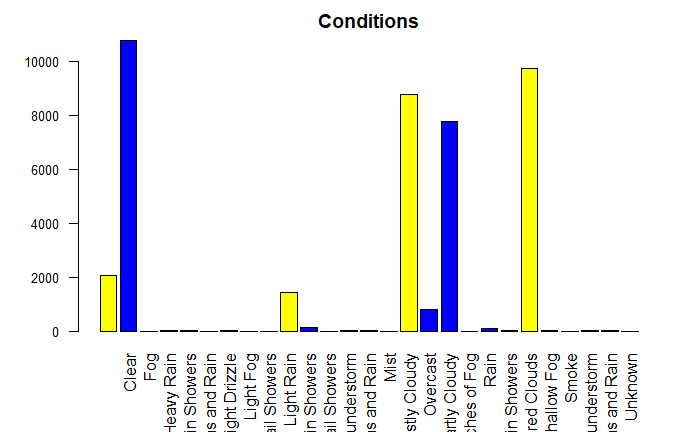

```r
barplot(table(ANTdf$Conditions),
        main= 'Conditions',las=2,col = BORdf$Conditions,cex.axis=0.8,cex.names=1)
```

```r
table(ANTdf$Conditions)
```

```
                                                    Clear                          Fog                   Heavy Rain           Heavy Rain Showers Heavy Thunderstorms and Rain
                        2104                        10974                            3                            8                           14                            3
               Light Drizzle                    Light Fog           Light Hail Showers                   Light Rain           Light Rain Showers     Light Small Hail Showers
                          41                            4                            3                         1426                          138                            1
          Light Thunderstorm Light Thunderstorms and Rain                         Mist                Mostly Cloudy                     Overcast                Partly Cloudy
                          19                           38                            1                         8833                          800                         7910
              Patches of Fog                         Rain                 Rain Showers             Scattered Clouds                  Shallow Fog                        Smoke
                           5                           93                           23                         9941                           10                            1
                Thunderstorm       Thunderstorms and Rain                      Unknown
                          34                           31                            5
```

```r
head(BORdf)
```

|  | Time | TemperatureC | Humidity | Wind_Direction | Conditions | DateUTC |
| --- | --- | --- | --- | --- | --- | --- |
| 1 | 2016-01-01 00:00:00 | 7 | 95 | South | Patches of Fog | 2015-12-31 23:00:00 |
| 2 | 2016-01-01 00:00:00 | 7 | 93 | South | Unknown | 2015-12-31 23:00:00 |
| 3 | 2016-01-01 00:30:00 | 6 | 100 | ESE | Mist | 2015-12-31 23:30:00 |
| 4 | 2016-01-01 01:00:00 | 6 | 98 | ESE | Partial Fog | 2016-01-01 00:00:00 |
| 5 | 2016-01-01 01:00:00 | 6 | 93 | ESE | Fog | 2016-01-01 00:00:00 |
| 6 | 2016-01-01 01:30:00 | 5 | 100 | SE | Fog | 2016-01-01 00:30:00 |

```r
as.POSIXct(BORdf$Time[1])
```

```
[1] "2016-01-01 CET"
```

```r
library(lubridate)
hour(BORdf$Time[1])
```

```
[1] 0
```

```r
d=date(BORdf$Time[1])
d
```

```
[1] "2016-01-01"
```

```r
class(BORdf$Time)
```

```
[1] "factor"
```

Extracting under Date format from the date factor in the column ‘Time’ to a new column called “Date”

```r
library(lubridate)
BORdf$Date<-as.Date(BORdf$Time)
tail(BORdf,2)
```

|  | Time | TemperatureC | Humidity | Wind_Direction | Conditions | DateUTC | Date |
| --- | --- | --- | --- | --- | --- | --- | --- |
| 42919 | 2017-08-30 23:00:00 | 17 | 88 | NNW | Mostly Cloudy | 2017-08-30 21:00:00 | 2017-08-30 |
| 42920 | 2017-08-30 23:30:00 | 17 | 88 | NW | Mostly Cloudy | 2017-08-30 21:30:00 | 2017-08-30 |

Extracting now the day of the week in a new column called ‘DoW’

The function ‘wday’ returns the day of the week as a decimal number (01-07, Sunday is 1) or an ordered factor(Sunday is first).

```r
BORdf$DoW<-wday(BORdf$Date)
```

Extracting now the day of the month in a new column called ‘DoM’,teh week of the year to ‘WoY’, the month of the year to “MoY”, the querter of the year to ‘QoY’

```r
BORdf$DoM<-mday(BORdf$Date)
BORdf$WoY<-week(BORdf$Date)
BORdf$MoY<-month(BORdf$Date)
BORdf$QoY<-quarter(BORdf$Date)
tail(BORdf)
```

|  | Time | TemperatureC | Humidity | Wind_Direction | Conditions | DateUTC | Date | DoW | DoM | WoY | MoY | QoY |
| --- | --- | --- | --- | --- | --- | --- | --- | --- | --- | --- | --- | --- |
| 42915 | 2017-08-30 22:00:00 | 18 | 75 | NNW | Clear | 2017-08-30 20:00:00 | 2017-08-30 | 4 | 30 | 35 | 8 | 3 |
| 42916 | 2017-08-30 22:00:00 | 18 | 77 | NNW | Mostly Cloudy | 2017-08-30 20:00:00 | 2017-08-30 | 4 | 30 | 35 | 8 | 3 |
| 42917 | 2017-08-30 22:30:00 | 17 | 88 | NNW | Light Rain | 2017-08-30 20:30:00 | 2017-08-30 | 4 | 30 | 35 | 8 | 3 |
| 42918 | 2017-08-30 23:00:00 | 17 | 84 | NNW | Clear | 2017-08-30 21:00:00 | 2017-08-30 | 4 | 30 | 35 | 8 | 3 |
| 42919 | 2017-08-30 23:00:00 | 17 | 88 | NNW | Mostly Cloudy | 2017-08-30 21:00:00 | 2017-08-30 | 4 | 30 | 35 | 8 | 3 |
| 42920 | 2017-08-30 23:30:00 | 17 | 88 | NW | Mostly Cloudy | 2017-08-30 21:30:00 | 2017-08-30 | 4 | 30 | 35 | 8 | 3 |

Creating a column called “schedule”" containing one of the following values: ‘a_day_off’, ‘before_a_day_off’, ‘holidays’ or ‘no_event’

```r
BORdf$schedule<-ifelse(BORdf$Date=='2016-01-01'| BORdf$Date=='2016-03-28'|BORdf$Date =='2016-05-01'| BORdf$Date=='2016-05-08'|
                       BORdf$Date=='2016-05-16'| BORdf$Date=='2016-07-14'| BORdf$Date=='2016-08-15'|
                       BORdf$Date=='2016-11-01'|BORdf$Date=='2016-11-11'|
                       BORdf$Date=='2017-01-01'| BORdf$Date=='2017-03-28'|BORdf$Date=='2017-05-01'| BORdf$Date=='2017-05-08'|
                       BORdf$Date=='2017-05-16'| BORdf$Date=='2017-07-14'| BORdf$Date=='2017-08-15'|BORdf$Date=='2017-11-01'|BORdf$Date=='2017-11-11',
                       'a_day_off',
                       ifelse(BORdf$Date+1=='2016-01-01'| BORdf$Date+1=='2016-03-28'|BORdf$Date+1 =='2016-05-01'| BORdf$Date+1=='2016-05-08'|
                       BORdf$Date+1=='2016-05-16'| BORdf$Date+1=='2016-07-14'| BORdf$Date+1=='2016-08-15'|
                       BORdf$Date+1=='2016-11-01'|BORdf$Date+1=='2016-11-11'|
                       BORdf$Date+1=='2017-01-01'| BORdf$Date+1=='2017-03-28'|BORdf$Date+1=='2017-05-01'| BORdf$Date+1=='2017-05-08'|
                       BORdf$Date+1=='2017-05-16'| BORdf$Date+1=='2017-07-14'| BORdf$Date+1=='2017-08-15'|BORdf$Date+1=='2017-11-01'|BORdf$Date+1=='2017-11-11',
                       'before_aday_off',
                       ifelse(BORdf$Date <'2016-01-04'| BORdf$Date >'2016-02-13'& BORdf$Date < '2016-02-29'| BORdf$Date >'2016-04-09'&
                       BORdf$Date <'2016-04-25'| BORdf$Date>'2016-05-04'& BORdf$Date<'2016-05-09'|
                       BORdf$Date>'2016-07-05'&BORdf$Date<'2016-09-01'|
                       BORdf$Date>'2016-10-19'& BORdf$Date<'2016-11-03'|BORdf$Date>'2016-12-17'&BORdf$Date<'2017-01-03'|
                       BORdf$Date>'2017-02-18'& BORdf$Date<'2017-03-06'| BORdf$Date>'2017-04-15'&BORdf$Date<'2017-05-02'|BORdf$Date>'2017-05-24'&BORdf$Date<'2017-05-29'|
                         BORdf$Date>'2017-07-08'&BORdf$Date<'2017-09-04',
                       'holidays',
                       'no_event')
                       ))
```

*Note: can use ‘with’ to avoid repeting Bordf$..

```r
BORdf$schedule<-as.factor(BORdf$schedule)
head(BORdf,3)
```

|  | Time | TemperatureC | Humidity | Wind_Direction | Conditions | DateUTC | Date | DoW | DoM | WoY | MoY | QoY | schedule |
| --- | --- | --- | --- | --- | --- | --- | --- | --- | --- | --- | --- | --- | --- |
| 1 | 2016-01-01 00:00:00 | 7 | 95 | South | Patches of Fog | 2015-12-31 23:00:00 | 2016-01-01 | 6 | 1 | 1 | 1 | 1 | a_day_off |
| 2 | 2016-01-01 00:00:00 | 7 | 93 | South | Unknown | 2015-12-31 23:00:00 | 2016-01-01 | 6 | 1 | 1 | 1 | 1 | a_day_off |
| 3 | 2016-01-01 00:30:00 | 6 | 100 | ESE | Mist | 2015-12-31 23:30:00 | 2016-01-01 | 6 | 1 | 1 | 1 | 1 | a_day_off |

```r
# check
subset(BORdf,Date=='2017-07-30')$schedule[1:5]
```

```
[1] holidays holidays holidays holidays holidays
Levels: a_day_off before_aday_off holidays no_event
```

Working with date( some examples)

```r
l=substring(BORdf$DateUTC[1],12,19)
l= as.factor(l)
print(l)
```

```
[1] 23:00:00
Levels: 23:00:00
```

```r
class(l)
```

```
[1] "factor"
```

```r
l=as.factor(l)
class(l)
```

```
[1] "factor"
```

```r
l<-as.POSIXct(l,format="%H:%M:%S")
l
```

```
[1] "2017-09-07 23:00:00 CEST"
```

```r
# if date non given, the current date is showed by default
```

```r
class(l)
```

```
[1] "POSIXct" "POSIXt"
```

```r
hour(l)
```

```
[1] 23
```

LET’S KEEP BUIDING OUR " CONTEXT" DATA SET Adding a column named ‘hour’ indicating, the class of this feature will be integrer

```r
BORdf$H<- hour(BORdf$Time)
colnames(BORdf)
```

```
 [1] "Time"           "TemperatureC"   "Humidity"       "Wind_Direction" "Conditions"     "DateUTC"        "Date"           "DoW"            "DoM"            "WoY"            "MoY"
[12] "QoY"            "schedule"       "H"
```

```r
class(BORdf$H)
```

```
[1] "integer"
```

Now, create a column containing !h:m:s, the class of this feature will be factor

```r
BORdf$HMS<-substring(BORdf$Time,12,19)# take from the 12th to 19th elements of the variable 'Time'
class(BORdf$HMS)
```

```
[1] "character"
```

converting this feature to factor

```r
BORdf$HMS<-as.factor(BORdf$HMS)
head(BORdf,1)
```

|  | Time | TemperatureC | Humidity | Wind_Direction | Conditions | DateUTC | Date | DoW | DoM | WoY | MoY | QoY | schedule | H | HMS |
| --- | --- | --- | --- | --- | --- | --- | --- | --- | --- | --- | --- | --- | --- | --- | --- |
| 1 | 2016-01-01 00:00:00 | 7 | 95 | South | Patches of Fog | 2015-12-31 23:00:00 | 2016-01-01 | 6 | 1 | 1 | 1 | 1 | a_day_off | 0 | 00:00:00 |

```r
table(BORdf$HMS)
```

```
00:00:00 00:30:00 01:00:00 01:30:00 02:00:00 02:30:00 03:00:00 03:30:00 04:00:00 04:30:00 05:00:00 05:30:00 06:00:00 06:30:00 07:00:00 07:30:00 08:00:00 08:30:00 09:00:00 09:30:00 10:00:00
    1170      609     1187      608     1199      607     1174      607     1180      608     1196      605     1168      606     1175      606     1207      605     1155      608     1180
10:30:00 11:00:00 11:30:00 12:00:00 12:30:00 13:00:00 13:30:00 14:00:00 14:30:00 15:00:00 15:30:00 16:00:00 16:30:00 17:00:00 17:30:00 18:00:00 18:30:00 19:00:00 19:30:00 20:00:00 20:30:00
     607     1202      606     1167      605     1176      608     1205      607     1161      608     1173      607     1205      608     1162      607     1165      606     1207      607
21:00:00 21:30:00 22:00:00 22:30:00 23:00:00 23:30:00
    1176      607     1166      608     1200      604
```

```r
summary(BORdf)
```

```
                  Time        TemperatureC      Humidity       Wind_Direction          Conditions                   DateUTC           Date                 DoW             DoM
 2016-03-27 00:00:00:    4   Min.   :-8.00   Min.   :  5.00   West    : 5013   Clear        :22444   2016-03-27 22:00:00:    4   Min.   :2016-01-01   Min.   :1.000   Min.   : 1.00
 2016-10-30 02:00:00:    4   1st Qu.: 9.00   1st Qu.: 57.00   WSW     : 3310   Overcast     : 4954   2017-03-26 22:00:00:    4   1st Qu.:2016-05-29   1st Qu.:2.000   1st Qu.: 8.00
 2017-03-26 00:00:00:    4   Median :14.00   Median : 76.00   North   : 3078   Mostly Cloudy: 4799   2015-12-31 23:00:00:    2   Median :2016-10-25   Median :4.000   Median :16.00
 2016-01-01 00:00:00:    2   Mean   :14.37   Mean   : 71.57   WNW     : 2932   Light Rain   : 2345   2016-01-01 00:00:00:    2   Mean   :2016-10-26   Mean   :3.999   Mean   :15.71
 2016-01-01 01:00:00:    2   3rd Qu.:19.00   3rd Qu.: 88.00   ESE     : 2730   Unknown      : 1597   2016-01-01 01:00:00:    2   3rd Qu.:2017-03-25   3rd Qu.:6.000   3rd Qu.:23.00
 2016-01-01 02:00:00:    2   Max.   :38.00   Max.   :100.00   Variable: 2596   Partly Cloudy: 1576   2016-01-01 02:00:00:    2   Max.   :2017-08-30   Max.   :7.000   Max.   :31.00
 (Other)            :42902                                    (Other) :23261   (Other)      : 5205   (Other)            :42904
      WoY             MoY              QoY                   schedule           H              HMS
 Min.   : 1.00   Min.   : 1.000   Min.   :1.000   a_day_off      : 1132   Min.   : 0.0   08:00:00: 1207
 1st Qu.:11.00   1st Qu.: 3.000   1st Qu.:1.000   before_aday_off: 1056   1st Qu.: 5.0   20:00:00: 1207
 Median :22.00   Median : 6.000   Median :2.000   holidays       :13718   Median :11.0   14:00:00: 1205
 Mean   :23.12   Mean   : 5.717   Mean   :2.256   no_event       :27014   Mean   :11.5   17:00:00: 1205
 3rd Qu.:33.00   3rd Qu.: 8.000   3rd Qu.:3.000                           3rd Qu.:17.0   11:00:00: 1202
 Max.   :53.00   Max.   :12.000   Max.   :4.000                           Max.   :23.0   23:00:00: 1200
                                                                                         (Other) :35694
```

```r
colnames(BORdf)
```

```
 [1] "Time"           "TemperatureC"   "Humidity"       "Wind_Direction" "Conditions"     "DateUTC"        "Date"           "DoW"            "DoM"            "WoY"            "MoY"
[12] "QoY"            "schedule"       "H"              "HMS"
```

```r
head(BORdf,2)
```

|  | Time | TemperatureC | Humidity | Wind_Direction | Conditions | DateUTC | Date | DoW | DoM | WoY | MoY | QoY | schedule | H | HMS |
| --- | --- | --- | --- | --- | --- | --- | --- | --- | --- | --- | --- | --- | --- | --- | --- |
| 1 | 2016-01-01 00:00:00 | 7 | 95 | South | Patches of Fog | 2015-12-31 23:00:00 | 2016-01-01 | 6 | 1 | 1 | 1 | 1 | a_day_off | 0 | 00:00:00 |
| 2 | 2016-01-01 00:00:00 | 7 | 93 | South | Unknown | 2015-12-31 23:00:00 | 2016-01-01 | 6 | 1 | 1 | 1 | 1 | a_day_off | 0 | 00:00:00 |

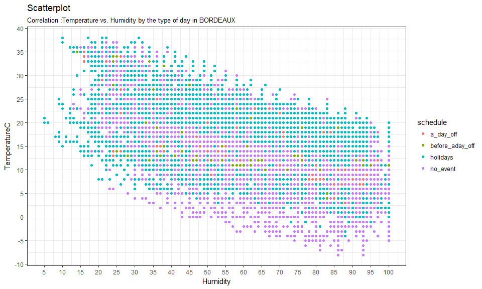

```r
ggplot(BORdf, aes(Humidity,TemperatureC))+ geom_point(aes(color = schedule)) +
scale_x_continuous("Humidity", breaks = seq(0,100,by = 5))+
scale_y_continuous("TemperatureC", breaks = seq(-10,110,by = 5))+
labs(subtitle="Correlation :Temperature vs. Humidity by the type of day in BORDEAUX")+
theme_bw() + labs(title="Scatterplot")
```

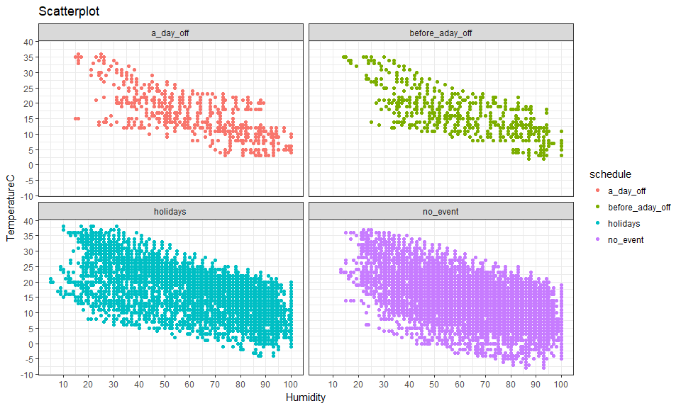

```r
# this code is from : "7 Visualizations You Should Learn in R | Rbloggers"
ggplot(BORdf, aes(Humidity,TemperatureC)) + geom_point(aes(color = schedule)) +
scale_x_continuous("Humidity", breaks = seq(0,110,10))+
scale_y_continuous("TemperatureC", breaks = seq(-10,40,5))+
theme_bw() + labs(title="Scatterplot") + facet_wrap( ~ schedule)
```

```r
sub1=subset(BORdf,TemperatureC < 0,select = c('schedule','DoW','MoY'))
table(sub1$schedule,sub1$DoW)
```

```
                    1   2   3   4   5   6   7
  a_day_off         0   0   0   0   0   0   0
  before_aday_off   0   0   0   0   0   0   0
  holidays          0   0   0  29  11   0   0
  no_event         48  29  35 144  94  68  67
```

```r
library(dplyr)
sub1<-tbl_df(sub1)# converting sub1 from df to table with 'dplyr' package, using filter to extract data ( no need subset anymore)
filter(sub1,schedule=='no_event'&DoW==7)
```

| schedule | DoW | MoY |
| --- | --- | --- |
| no_event | 7 | 1 |
| no_event | 7 | 1 |
| no_event | 7 | 1 |
| no_event | 7 | 1 |
| no_event | 7 | 1 |
| no_event | 7 | 1 |
| no_event | 7 | 1 |
| no_event | 7 | 1 |
| no_event | 7 | 1 |
| no_event | 7 | 1 |

[output cut: 57 more lines]

```r
write.csv(BORdf, file = 'Bordeaux_context.csv',row.names = F)
```